# Investigating a Suspected Non-Linear Effect: Simulation and Model Comparison

Julian

2026-09-17

This notebook demonstrates how to deal with a predictor `x` that may have a non-linear relationship with an outcome `y`. The following code shows - based on a simulated example - how a naive model assuming a linear effect fails, and how alternative models using splines and Gaussian processes can recover such effect.

## Simulation

We simulate a data set where $x \in [0; 20]$ affects $y$ both linearly with a slope of $\beta_x = 0.4$, but also has a sinusoidal wiggle around this linear trend. This could represent a seasonal or saturating-with-oscillation pattern

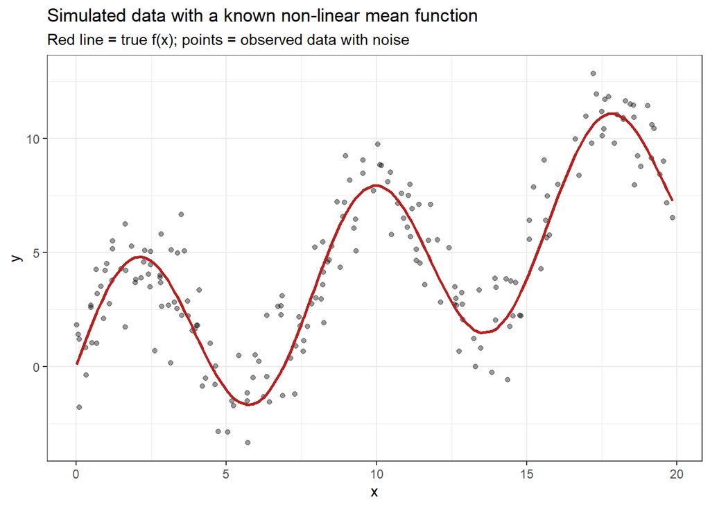

```r
n <- 200

f_true <- function(x) 0.4 * x + 4 * sin(0.8 * x)

sim_data <- tibble(
  x = runif(n, min = 0, max = 20)
) %>%
  mutate(
    mu_true = f_true(x),
    y = mu_true + rnorm(n, mean = 0, sd = 1.5)
  ) %>%
  arrange(x)

sim_data %>%
  ggplot(aes(x = x)) +
  geom_point(aes(y = y), alpha = 0.4) +
  geom_line(aes(y = mu_true), colour = "firebrick", linewidth = 1) +
  labs(
    title = "Simulated data with a known non-linear mean function",
    subtitle = "Red line = true f(x); points = observed data with noise",
    y = "y"
  ) +
  theme_bw()
```

## Data Analysis

In the following subsections, we compare multiple models in their ability to recover this true effect.

### Linear Model

We first fit the model an analyst might reach for by default: a plain linear effect of `x` on the mean of `y`.

```r
m.linear <- brm(
  y ~ x,
  data   = sim_data,
  family = gaussian(),
  prior  = c(
    prior(normal(0, 5), class = "Intercept"),
    prior(normal(0, 5), class = "b"),
    prior(exponential(1), class = "sigma")
  ),
  chains = 4, cores = 4, iter = 2000, seed = 1,
  refresh = 0,
  file = "../../fits/m.sin.naive", file_refit = "on_change"
)
summary(m.linear)
```

```
##  Family: gaussian
##   Links: mu = identity
## Formula: y ~ x
##    Data: sim_data (Number of observations: 200)
##   Draws: 4 chains, each with iter = 2000; warmup = 1000; thin = 1;
##          total post-warmup draws = 4000
##
## Regression Coefficients:
##           Estimate Est.Error l-95% CI u-95% CI Rhat Bulk_ESS Tail_ESS
## Intercept     1.03      0.36     0.32     1.71 1.00     3903     3367
## x             0.38      0.03     0.31     0.44 1.00     3907     3010
##
## Further Distributional Parameters:
##       Estimate Est.Error l-95% CI u-95% CI Rhat Bulk_ESS Tail_ESS
## sigma     2.86      0.14     2.59     3.16 1.00     4424     2992
##
## Draws were sampled using sampling(NUTS). For each parameter, Bulk_ESS
## and Tail_ESS are effective sample size measures, and Rhat is the potential
## scale reduction factor on split chains (at convergence, Rhat = 1).
```

Overlaying the fitted regression line on the true function already shows that this naive model can only capture the overall linear trend but misses the oscillation.

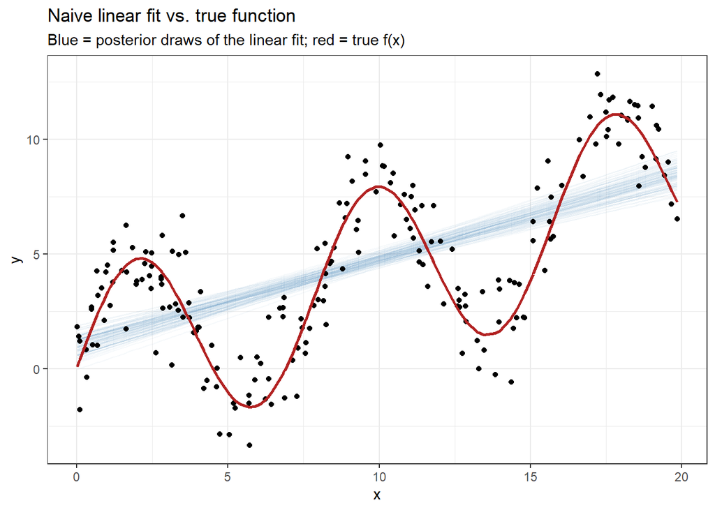

```r
sim_data %>%
  add_epred_draws(m.linear, ndraws = 100) %>%
  ggplot(aes(x = x, y = y)) +
  geom_line(aes(y = .epred, group = .draw), alpha = 0.05, colour = "steelblue") +
  geom_point(alpha = 0.35) +
  geom_line(aes(y = mu_true), colour = "firebrick", linewidth = 1) +
  labs(
    title = "Naive linear fit vs. true function",
    subtitle = "Blue = posterior draws of the linear fit; red = true f(x)",
    y = "y"
  ) +
  theme_bw()
```

The residual plot clearly shows the issue. A well-specified model should leave residuals scattered randomly around zero with no structure. Instead, we see a clear, systematic wave pattern — a textbook sign of an unmodelled non-linear effect.

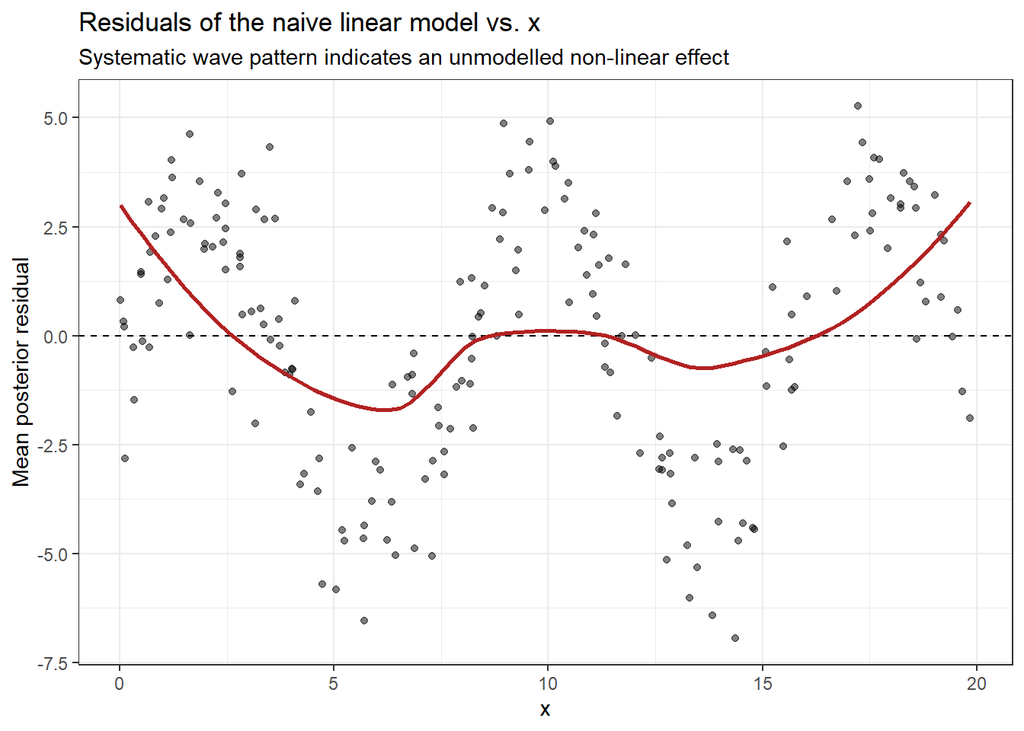

```r
sim_data %>%
  add_residual_draws(m.linear) %>%
  group_by(x) %>%
  summarise(resid_mean = mean(.residual), .groups = "drop") %>%
  ggplot(aes(x = x, y = resid_mean)) +
  geom_hline(yintercept = 0, linetype = "dashed") +
  geom_point(alpha = 0.5) +
  geom_smooth(formula = y~x, method = "loess", se = FALSE, colour = "firebrick") +
  labs(
    title = "Residuals of the naive linear model vs. x",
    subtitle = "Systematic wave pattern indicates an unmodelled non-linear effect",
    y = "Mean posterior residual"
  ) +
  theme_bw()
```

Instead of making an a-priori assumption about the shape of the effect, we can fit flexible specifications that can recover a wide range of shapes (including the linear one in case it were actually correct).

### B-spline smooth

One approach is by modelling the predictor as a B-spline, i.e., a piecewise polynomial of maximum order `k`, using `mgcv::s()`.

```r
m.spline <- brm(
  y ~ s(x, bs = "bs", k = 10),
  data   = sim_data,
  family = gaussian(),
  prior  = c(
    prior(normal(0, 5), class = "Intercept"),
    prior(exponential(1), class = "sigma")
  ),
  chains = 4, cores = 4, iter = 2000, seed = 2,
  control = list(adapt_delta = 0.95), refresh = 0,
  file = "../../fits/m.sin.spline", file_refit = "on_change"
)
summary(m.spline)
```

```
##  Family: gaussian
##   Links: mu = identity
## Formula: y ~ s(x, bs = "bs", k = 10)
##    Data: sim_data (Number of observations: 200)
##   Draws: 4 chains, each with iter = 2000; warmup = 1000; thin = 1;
##          total post-warmup draws = 4000
##
## Smoothing Spline Hyperparameters:
##           Estimate Est.Error l-95% CI u-95% CI Rhat Bulk_ESS Tail_ESS
## sds(sx_1)     5.69      1.48     3.58     9.18 1.00     1444     1859
##
## Regression Coefficients:
##           Estimate Est.Error l-95% CI u-95% CI Rhat Bulk_ESS Tail_ESS
## Intercept     4.46      0.10     4.26     4.65 1.00     4115     2901
## sx_1          3.19      1.38     0.62     5.78 1.01     1427     1894
##
## Further Distributional Parameters:
##       Estimate Est.Error l-95% CI u-95% CI Rhat Bulk_ESS Tail_ESS
## sigma     1.42      0.07     1.28     1.57 1.00     3649     2468
##
## Draws were sampled using sampling(NUTS). For each parameter, Bulk_ESS
## and Tail_ESS are effective sample size measures, and Rhat is the potential
## scale reduction factor on split chains (at convergence, Rhat = 1).
```

The model summary contains two unique outputs for B-spline models:

- `sx_1` is the unpenalized part of the spline basis, i.e., its linear/null-space component. It can be interpreted like a ordinary regression coefficient and allows inference about the overall linear trend.
- `sds(sx_1)` is the estimated standard deviation of the penalized (i.e., “wiggly”) basis coefficients (i.e., the Bayesian analogue of the smoothing parameter). A posterior concentrated implies strong shrinkage, i.e., evidence against meaningful non-linearity, while a posterior not consistant with 0 supports deviation from lienarity.

The individual penalized coefficients themselves (`s_sx_1_1`, `s_sx_1_2`, …) are not printed by default (like random-effect levels), but can be accessed via `as_draws_df(model) %>% select(starts_with("s_"))`.

### Gaussian process term

An alternative is a Gaussian process (GP) term, which is a stochastic process such that every finite collection of random variables has a multivariate distribution.

```r
m.gp <- brm(
  #y ~ gp(x),
  y ~ gp(x, k = 20, c = 5/4), # better-scaling HSGP variant
  data   = sim_data,
  family = gaussian(),
  prior  = c(
    prior(normal(0, 5), class = "Intercept"),
    prior(exponential(1), class = "sigma")
  ),
  chains = 4, cores = 4, iter = 2000, seed = 3,
  control = list(adapt_delta = 0.95), refresh = 0,
  file = "../../fits/m.sin.gp", file_refit = "on_change"
)
summary(m.gp)
```

```
##  Family: gaussian
##   Links: mu = identity
## Formula: y ~ gp(x, k = 20, c = 5/4)
##    Data: sim_data (Number of observations: 200)
##   Draws: 4 chains, each with iter = 2000; warmup = 1000; thin = 1;
##          total post-warmup draws = 4000
##
## Gaussian Process Hyperparameters:
##             Estimate Est.Error l-95% CI u-95% CI Rhat Bulk_ESS Tail_ESS
## sdgp(gpx)       4.76      1.40     2.84     8.12 1.00     2259     2285
## lscale(gpx)     0.08      0.04     0.02     0.15 1.00     1347     2110
##
## Regression Coefficients:
##           Estimate Est.Error l-95% CI u-95% CI Rhat Bulk_ESS Tail_ESS
## Intercept     3.47      1.85    -0.85     6.64 1.00     2834     2291
##
## Further Distributional Parameters:
##       Estimate Est.Error l-95% CI u-95% CI Rhat Bulk_ESS Tail_ESS
## sigma     1.39      0.07     1.26     1.55 1.00     6166     2799
##
## Draws were sampled using sampling(NUTS). For each parameter, Bulk_ESS
## and Tail_ESS are effective sample size measures, and Rhat is the potential
## scale reduction factor on split chains (at convergence, Rhat = 1).
```

Since an exact Gaussian process term is computationally expensive, `brms` offers a Hilbert-space approximate GP (HSGP), i.e., a GP with a fixed set of basis functions (conceptually close to splines) that scales better. For example, `brms::gp(x, k = 20, c = 5/4)` defines `k = 20` basis functions and approximation boundary beyond the data range of `c = 5/4`. Alternative ways to speed up the computation is to use `backend = "cmdstanr` (instead of `backend = "rstan`) which is faster for GP models specifically, or a lower `adapt_delta = 0.8` (instead of 0.95 here).

The GP’s estimated length-scale (`lscale`) is directly interpretable: a short length-scale relative to the range of `x` (here: $[0; 20]$) indicates the function wiggles quickly (strong non-linearity), while a length-scale comparable to or larger than the whole range of `x` would indicate the fit is close to linear/flat.

```r
m.gp %>%
  as_draws_df() %>%
  select(starts_with("lscale")) %>%
  summarise(across(everything(), list(mean = mean, q5 = ~ quantile(.x, 0.05), q95 = ~ quantile(.x, 0.95))))
```

```
## # A tibble: 1 × 3
##   lscale_gpx_mean lscale_gpx_q5 lscale_gpx_q95
##             <dbl>         <dbl>          <dbl>
## 1          0.0777        0.0202          0.141
```

## Evaluation

### Marginal Effects

The marginal effect of `x` on `y` in the two complex models allows a better inference. We plot each model’s estimated conditional mean function against the true `f(x)` used in the simulation.

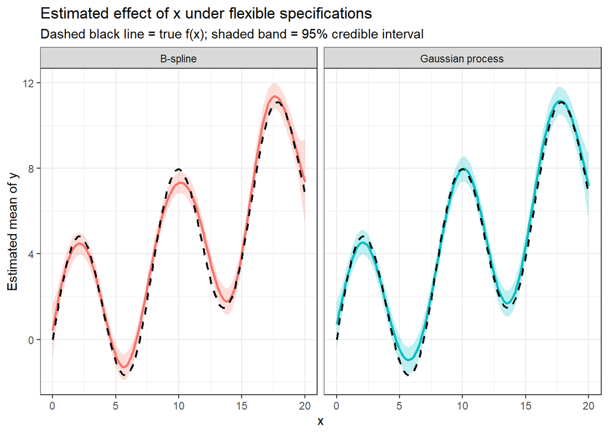

```r
new_x <- tibble(x = seq(0, 20, length.out = 200))

pred_spline <- new_x %>%
  add_epred_draws(m.spline) %>%
  group_by(x) %>%
  summarise(
    estimate = mean(.epred),
    lower    = quantile(.epred, 0.025),
    upper    = quantile(.epred, 0.975),
    .groups  = "drop"
  ) %>%
  mutate(model = "B-spline")

pred_gp <- new_x %>%
  add_epred_draws(m.gp) %>%
  group_by(x) %>%
  summarise(
    estimate = mean(.epred),
    lower    = quantile(.epred, 0.025),
    upper    = quantile(.epred, 0.975),
    .groups  = "drop"
  ) %>%
  mutate(model = "Gaussian process")

bind_rows(pred_spline, pred_gp) %>%
  ggplot(aes(x = x, y = estimate)) +
  geom_ribbon(aes(ymin = lower, ymax = upper, fill = model), alpha = 0.25) +
  geom_line(aes(colour = model), linewidth = 1) +
  geom_line(
    data = tibble(x = new_x$x, mu_true = f_true(new_x$x)),
    aes(x = x, y = mu_true),
    colour = "black", linetype = "dashed", linewidth = 0.8
  ) +
  facet_wrap(~model) +
  labs(
    title = "Estimated effect of x under flexible specifications",
    subtitle = "Dashed black line = true f(x); shaded band = 95% credible interval",
    y = "Estimated mean of y"
  ) +
  theme_bw() +
  theme(legend.position = "none")
```

### Predictive Accuracy

We now compare all three models’ out-of-sample predictive accuracy. This is a useful *complement* to the plots above — not a replacement — since it gives a single, easily reportable summary of the evidence.

```r
m.linear <- add_criterion(m.linear, "loo")
```

```
## Automatically saving the model object in '../../fits/m.sin.naive.rds'
```

```r
m.spline <- add_criterion(m.spline, "loo")
```

```
## Automatically saving the model object in '../../fits/m.sin.spline.rds'
```

```r
m.gp     <- add_criterion(m.gp, "loo")
```

```
## Automatically saving the model object in '../../fits/m.sin.gp.rds'
```

```r
loo_compare(m.linear, m.spline, m.gp)
```

```
##          elpd_diff se_diff
## m.gp        0.0       0.0
## m.spline   -3.1       2.7
## m.linear -140.1      11.0
```

Clearly the linear model `m.linear` fails to predict out of sample. The GP model `m.gp` performs best. Since the `elpd_diff` is not more than twice than its `se_diff`, the B-spline model `m.spline` can be considered of nearly equivalent predictive accuracy.

Before trusting the LOO comparison, check that the importance-sampling approximation was reliable for the flexible models (few or no observations with Pareto k > 0.7):

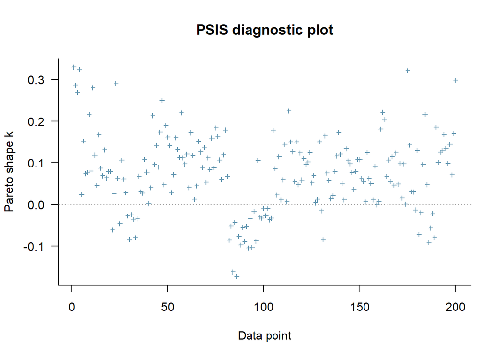

```r
loo(m.spline) %>% plot(label_points = TRUE)
```

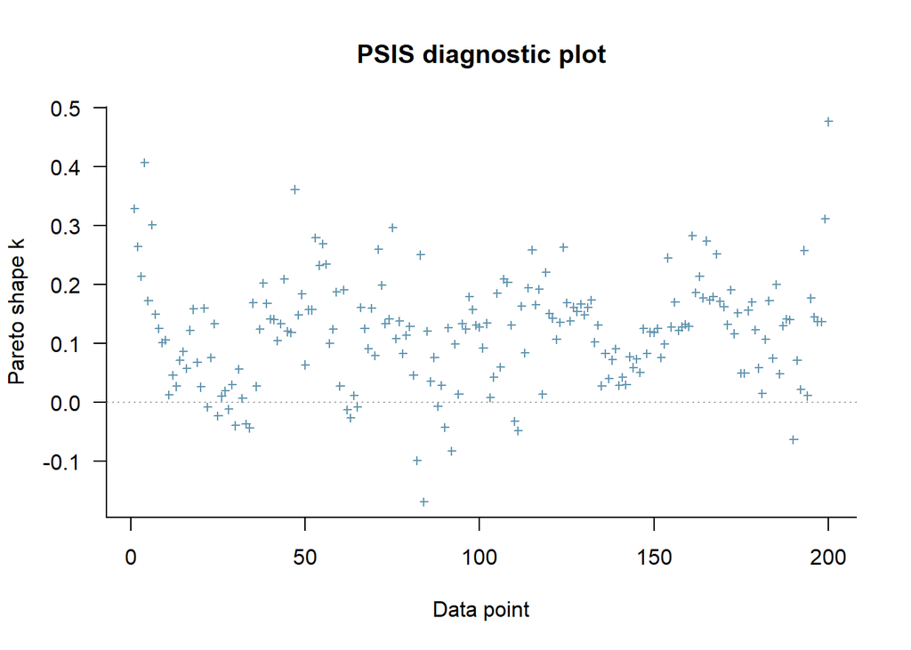

```r
loo(m.gp) %>% plot(label_points = TRUE)
```

### Alternative: Stacking Weights

The predictive stacking weights across all three models reflects genuine uncertainty about functional form rather than collapsing it into a binary decision:

```r
loo_model_weights(
  m.linear, m.spline, m.gp,
  model_names = c("linear", "spline", "gp"),
  method = "stacking"
)
```

```
## Method: stacking
## ------
##        weight
## linear 0.000
## spline 0.068
## gp     0.932
```

Since the linear model receives a weight close to zero, that’s further corroborating evidence — on top of the plots and the LOO comparison — that the effect of `x` is genuinely non-linear.